# Fathers’ involvement in children’s language development: A meta-analysis

September 8, 2018

## Methods

A preliminary search on Web of Science yielded 4991 articles, of which 92 met our inclusion criteria.

A librarian wrote syntax for Web of Science, PsychInfo, and ERIC, based on meta-data from our selected articles

This resulted in 2194 relevant records. Removal of duplicates left 1786 abstracts to evaluate.

This yielded 52 new articles, resulting in a total of 144.

Of these, 46 reported sufficient statistical information to compute a total of 377 effect sizes.

## Sample 2

Observed effect sizes ranged from -0.65 to 0.73 (\(M_r = 0.07\), \(SD = 0.22\)).

Sample sizes ranged from 8 to 5190 participants (\(M_n = 185.37\), \(SD = 413.82\)). Several studies reported multiple effect sizes (1 to 54, with most reporting 1 effect size).

## Standard meta-analysis

Multilevel meta-analysis for dependent effect sizes (Van den Noortgate et al., 2013)

**Overall effect size:**

\(\hat{\rho} = 0.11, 95% CI: [0.07, 0.15]\)

**Test for residual heterogeneity:**

\(Q(376) = 2666.44, p = 0\)

**\(I^2\) (Higgins & Thompson, 2002):**

Total \(I^2 = 88.01\%\) Between studies: \(I^2_b = 31.78\%\) Within studies: \(I^2_w = 56.22\%\)

## Publication bias

[interactive chart not shown]

Funnel plot asymmetry test: \(z = -1.24, p = 0.22\)

File drawer analysis: \(K = 2.6823\times 10^{4}\)

## Moderator analyses

## Recursive pre-selection

Large number of potential moderators coded (60)

Recursive pre-selection of moderators, 100 replications

Any moderator selected in 30% of replications was retained

Algorithm:

1. Start with all moderators
2. Conduct random-effects metaforest, with 2000 trees
3. **If** no moderators have negative importance values, or only one moderator, return the resulting model
4. **Else**, drop the variable with most negative variable importance, go back to Step 2

## Recursive pre-selection results

| Category | Selected | Dropped |
| --- | --- | --- |
| sc |  | pub year, impact factor that year |
| sa | began finished, pop dens | data year, age m iv, age m dv, p male, age m f, p single parent, country, p hispanic f, p black f, p asian f, p otherethnic f, p low ses family, p bilingual, p bio, p intact, p firstborn, larger study… |
| de | longitudinal | larger study |
| iv | qualitative, assessment, location, informant, validity, type cat | reliability |
| dv | type, assessment, location, informant, timelag, validity, instrumentname cat | reliability |
| es | reverse coded, partial, controls | type |

## Metaforest analysis

Metaforest analysis (R-package , Van Lissa, 2017)

Clustered by study

Two parallel forests (10.000 trees each) for unbiased prediction error (see Janitza, Celik, & Boulesteix, 2016)

### Model tuning

- Tuning grid:
  - Weights (“random”, “fixed”, “uniform”),
  - Candidate variables (2, 4, 6)
  - Min. node size = (2, 4, 6)
- 10-fold grouped cross-validation

Based on RMSE, the optimal model used uniform weights, 4 candidate variables at each split, and min node size of 2.

## Results

This analysis had an \(R^2_{cv} = 0.09\)

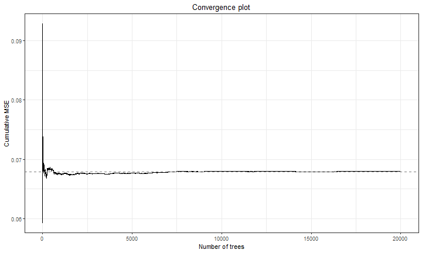

## Variable importance

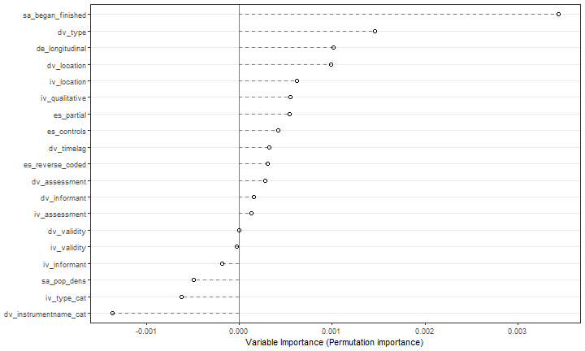

## Bivariate marginal associations 1/2

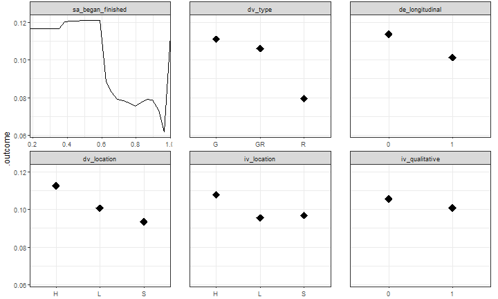

## Bivariate marginal associations 2/2

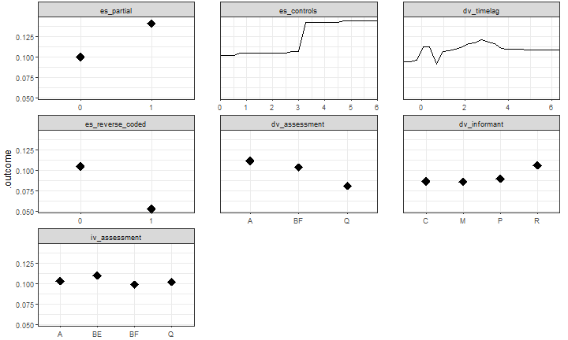

## Conclusions

**Substantive**

- Stronger effects for **generative-** than **receptive** language

**Methodological**

- Stronger effects for research at home (ecological validity?)
- Stronger effects for assessments/observations than questionnaires
- Stronger effects for trained researchers than for parent/self-reports

**Statistical**

- Stronger effects for cross-sectional than longitudinal research (dissipation over time)
- High dropout rate: Higher effect size (selection effect)
- Partial correlations tend to be stronger, especially with more controls

## Implications for adolescence

Fathers continue to be relevant

Instead of language development, examine cognitive development